# Autocorrelación espacial

Leccion 04

Omar E. Barrantes Sotela

## Importancia

La autocorrelación espacial es un procedimiento intrínsecamente geográfico. Ayuda a establecer el **comportamiento** de la información georreferenciada a *diferentes escalas*, en particular el tipo de asociación existente entre **unidades espaciales vecinas**.

Capacidad para estudiar la **forma** en que un **fenómeno** se **irradia** a través de las *unidades espaciales*, y si tal conducta corresponde a algún *modelo de difusión* conocido o bien registra la segregación espacial de alguna característica.

Refleja el **grado** en que objetos o actividades en una unidad geográfica son **similares** a los objetos o actividades en **unidades geográficas próximas**.

## Ancedentes históricos

El **Índice de Moran** (*Moran’s I*) fue desarrollado a finales de los años 40’s por **Patrick Alfred Pierce Moran**. Estadístico australiano, que es más conocido por sus contribuciones a la genética de poblaciones.

En la actualidad es ampliamente utilizado en la Geografía, por medio de los SIG. Destacan aplicaciones en los campos de la Geografía de la salud y humana.

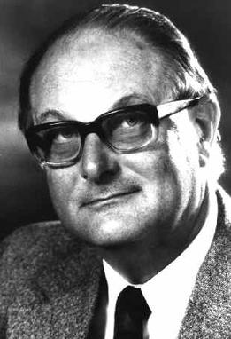

Paddy Moran

# Fundamento teórico

## Primera Ley de la Geografía

El principio de autocorrelación espacial, tiene sustento en el **principio de Tobler** (Miller, 2004; Tobler, 1970), que plantea:

**Todas las cosas están relacionadas entre sí, pero las cosas más próximas en el espacio tienen una relación mayor que las distantes.**

> Es un concepto similar al de **dependencia espacial** que constituye la base de la **geoestadística**.

# ¿Qué es un vecino?

## Vencidad

La mayoría de los análisis de AE se consideran las **relaciones de vecinos próximos**, ya que define la **matriz de pesos** de las unidades espaciales. De ahí la importancia de establecer los **criterios de vecindad**. Depende del tipo de representación espacial raster (**celdas**) o vector (**puntos-segmentos-polígonos**)

- Unidades espaciales que limitan con los vértices de otros elementos.
- Unidades espaciales que limitan con los segmentos de otros elementos.
- Unidades a un determinado radio o distancia.

## Patrones para analizar la vencindad

Es posible usar la lógica del movimiento de las piezas del ajedrez.

[figure not shown]

Alfil

[figure not shown]

Torre

[figure not shown]

Reina

## Demostración

[figure not shown]

Demostración de vencindad según vértices o segmentos.

# Definición I Moran

## Estadística de Producto cruzado

$$I = \frac{N}{W} \frac{\sum _{i}\sum _{j}w_{ij}(x_{i}-{\bar {x}})(x_{j} - \bar{x})} {\sum _{i}(x_{i}-{\bar{x}})^{2}}$$

**Nota**

- Se puede sustituir por $z = (x_{i}-{\bar {x}})$: la desviación desde la media.
- Similar al coeficiente de correlación.
- Valor depende de la matriz de pesos $W$.

## Valor esperado

Se calcula de la siguiente manera:

$$E(I)=\frac{-1}{N-1}$$

## I Moran (Dispersión)

El I Moran tiene el mismo intervalo del coeficiente de correlación.

- -1 : Es una agrupación perfecta de valores disimiles (Se puede considerar como una dispersión perfecta).

[figure not shown]

Patrón Disperso

## I Moran (Sin Autocorrelación)

El I Moran tiene el mismo intervalo del coeficiente de correlación.

- 0 : No existe autocorrelación (aleatoriedad perfecta).

[figure not shown]

Patrón Aleatorio

## I Moran (Agrupación)

El I Moran tiene el mismo intervalo del coeficiente de correlación.

- +1 : Indica una agrupación perfecta de valores similares (es lo opuesto a la dispersión).

[figure not shown]

Patrón Agrupado

## Matriz de dispersión AE

En el año de 1993 Luc Anselin presenta el **Moran Scatterplot** (GeoDa), una herramienta de análisis que permite observar en un gráfico de dispersión el comportamiento de cada unidad espacial.

## El Análisis local del I Moran

Esta novedad fue uno de los primeros pasos hacia el **análisis local**, es decir la desagregación del valor global de AE. El gráfico de dispersión se puede dividir en **cuatro cuadrantes** comenzando por el primero en la parte superior derecha y siguiendo en sentido de las agujas del reloj con los siguientes cuadrantes.

[figure not shown]

Gráfico de dispersión

## El gráfico de dispersión (I Parte)

- **Cuadrante I**: Unidades espaciales con **valores superiores a la media** que, a su vez, también cuentan con vecinos con valores altos (situación **alto-alto**, también conocidos como **hot spots**).
- **Cuadrante III**: La situación inversa al cuadrante I (situación **bajo-bajo**, también denominados **cold spots**). Ambos cuadrantes permiten detectar los *clusters* o agrupamientos de unidades espaciales con valores similares a los de sus vecinos.

[figure not shown]

Gráfico de dispersión

## El gráfico de dispersión (II Parte)

- **Cuadrante IV**: Están los **outliers espaciales** responden a contextos mixtos. Unidades espaciales con valores bajos (inferiores a la media) con vecinos que registran valores altos (situación **bajo-alto**).
- **Cuadrante II**: El escenario opuesto al cuadrante IV (situación **alto-bajo**).

[figure not shown]

Gráfico de dispersión

## Los outliners

La importancia de los **outliers** radica en que **NO** responden al *principio de AE* ya que el valor de las unidades espaciales que poseen a estas características se diferencia de los valores de sus vecinos. Además, por su carácter atípico sirven, para **detectar errores** en el ingreso de la información, ya sea de forma accidental o deliberada.

## Reflexión

*“Ahora, la razón por la que creemos que la informática es sobre computadoras es más o menos la misma razón por la que los egipcios pensaban que la geometría era sobre instrumentos topográficos. Y es decir, cuando un campo recién comienza y realmente no lo entiendes muy bien, es muy fácil confundir la esencia de lo que estás haciendo con las herramientas que usas.”*

Hal Abelson

## ¿Preguntas?

## Referencias

[figure not shown]

Escuela de Ciencias Geográficas

Miller, H. J. (2004). Tobler’s First Law and Spatial Analysis. *Annals of the Association of American Geographers*, *94*(2), 284-289. https://doi.org/10.1111/j.1467-8306.2004.09402005.x

Tobler, W. R. (1970). A Computer Movie Simulating Urban Growth in the Detroit Region. *Economic Geography*, *46*, 234-240. http://www.jstor.org/stable/143141